# PCA Biplot with the Iris Dataset

Oğuzhan Işılay

# 0) Goal of this tutorial

In the PCA plot (PC1–PC2) we see that species are separated.

But an important question remains:

**Which variables create this separation?**

A **biplot** helps us answer this.

In a biplot:

- Points = samples (flowers)
- Arrows = variables (Sepal/Petal measurements)

So we can see **samples and variables in the same plot.**

# 1) Load package and dataset

```r
# install.packages("ggplot2")  # run once if needed
library(ggplot2)

# Load the iris dataset
data(iris)

# PCA works only with numeric variables
iris_numeric <- iris[, 1:4]
```

# 2) Run PCA

Before PCA we scale the data.

This is important because variables can have different ranges.

```r
# Run PCA with scaling
pca_result <- prcomp(iris_numeric, scale. = TRUE)
```

# 3) Two important PCA outputs

A biplot uses two things:

- **Scores** (sample coordinates)
- **Loadings** (variable contributions)

## 3.1 Scores (sample coordinates)

`pca_result$x` shows where each sample is located in PCA space.

```r
# Convert scores to a data frame
scores <- as.data.frame(pca_result$x)

# Add species label (for coloring)
scores$Species <- iris$Species
```

## 3.2 Loadings (variable contributions)

`pca_result$rotation` shows how variables influence the PCs.

These values create the arrows in the biplot.

```r
# Extract loadings
loadings <- as.data.frame(pca_result$rotation)

# Add variable names
loadings$Variable <- rownames(loadings)
```

# 4) Quick biplot (base R)

This plot is simple but good for understanding the idea.

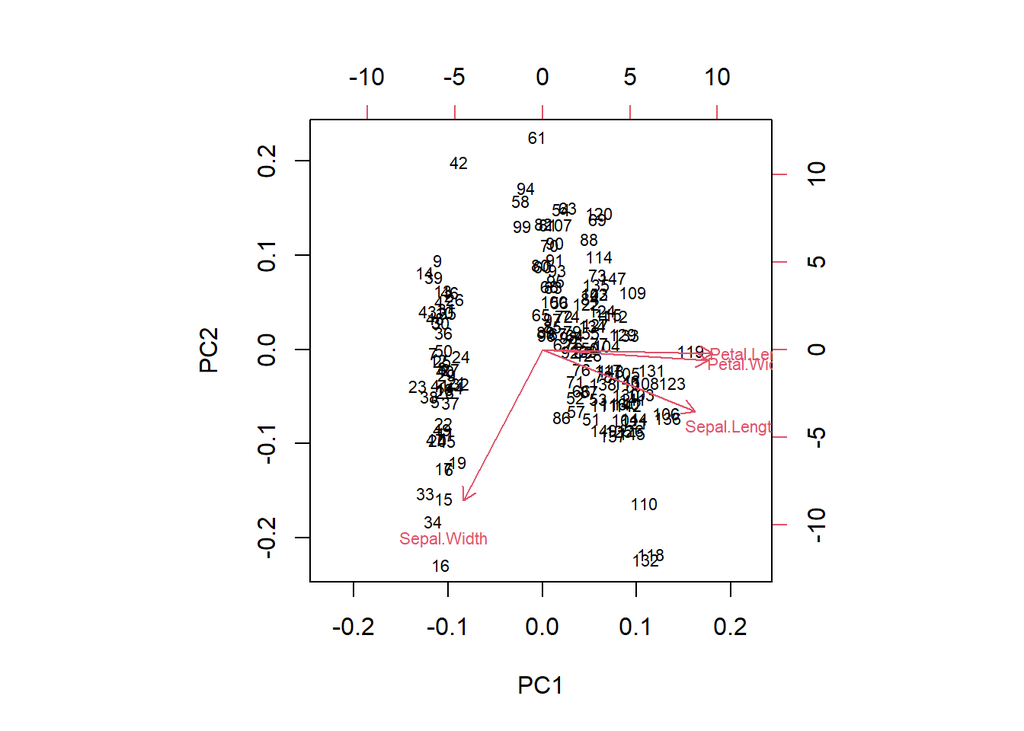

```r
biplot(pca_result, cex = 0.7)
```

# 5) Better biplot using ggplot

We now create a cleaner plot.

Arrows can be small, so we scale them.

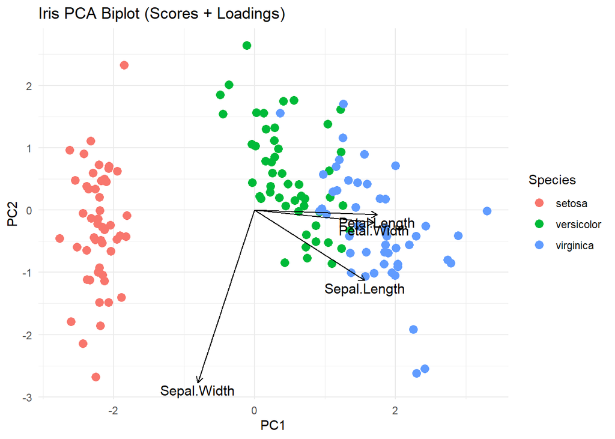

```r
# Arrow scaling factor
# Loadings arrows can be very small, so we multiply them to make them visible
scale_factor <- 3

# Create PCA biplot
# PC1 and PC2 are the first two principal components
ggplot(scores, aes(x = PC1, y = PC2, color = Species)) +

  # Plot the samples (flowers)
  # Each point represents one sample
  geom_point(size = 3) +

  # Draw arrows for variables (loadings)
  # Arrows start from the origin (0,0)
  geom_segment(
    data = loadings,
    aes(x = 0, y = 0,
        xend = PC1 * scale_factor,
        yend = PC2 * scale_factor),
    arrow = arrow(length = unit(0.2, "cm")),
    inherit.aes = FALSE
  ) +

  # Add variable names at the end of arrows
  # These labels show which measurement each arrow represents
  geom_text(
    data = loadings,
    aes(x = PC1 * scale_factor,
        y = PC2 * scale_factor,
        label = Variable),
    size = 4,
    vjust = 1.2,
    inherit.aes = FALSE
  ) +

  # Label the axes
  xlab("PC1") +
  ylab("PC2") +

  # Title of the plot
  ggtitle("Iris PCA Biplot (Scores + Loadings)") +

  # Use a clean theme
  theme_minimal()
```

# 6) How to read a biplot (simple)

When reading a biplot, focus on three things.

## 6.1 Points (samples)

- Points close together → samples are similar
- Separate clusters → groups are different

## 6.2 Arrows (variables)

- The arrow direction shows where the variable increases
- Longer arrows usually mean stronger influence on the PCs

## 6.3 Expected result for the iris dataset

In the iris dataset we usually see:

- **Petal.Length** and **Petal.Width** have strong influence
- **Setosa** separates clearly from the other species
- **Versicolor** and **Virginica** are closer and may overlap